# Predicting remaining useful life for turbofan engines

Wojciech Maślakiewicz

02 03 2022

# 1 Introduction

The objective of a predictive maintenance task is to predict failure of a certain machine or predict how much time is left for them before they brake.

In this project I tackle the second instance of the problem which can be formulated a s a regression task.

Namely, I use the NASA turbofan dataset to predict the Remaining Usefull Life of turbofan engines.

As every engine will certainly brake after some time, the key question to answer is **when will it brake?**

The dataset is pre-splitted into train and test set.

In the train set we observe engines that run to the point of failure. In other words, we observe sensors of a running engine, the after some time it develops a fault which causes it to ultimately stop after some period and then the engine is no longer observed. It is not a problem that we observe only engines that ultimately broke, as we are not trying to answer the question **whether the engine will brake** bu **when will it brake**.

In the test set we observe the engines work only for some period of time, possibly before any fault even occurred and our task is to predict the Remaining Useful Life of the given engines.

I chose 2 out of 4 datasets provided in the NASA dataset. The first one contains 100 engine units which end their work with one type of fault and run under one operational setting.

# 2 Preprocessing

## 2.1 Importing the raw data and preprocessing

Let’s import the raw datasets…

```r
# putting dataframes' names on one list
# DATAS(imple) and DATAC(omplex)
data_train_names <- paste0("data",1:4)
data_test_names <- paste0("test_data",1:4)
data_rul_names <- paste0("rul",1:4)

data_names <- c(data_train_names,data_test_names,data_rul_names)
# putting names of desired files on one list
train_file_names <- c("train_FD001.txt","train_FD002.txt","train_FD003.txt","train_FD004.txt")
test_file_names <- c("test_FD001.txt","test_FD002.txt","test_FD003.txt","test_FD004.txt")
rul_file_names <- c("RUL_FD001.txt","RUL_FD002.txt","RUL_FD003.txt","RUL_FD004.txt")

file_names <- c(train_file_names,test_file_names,rul_file_names)

for (i in  seq_along( file_names ) ) {
  path <- paste0("../../raw_data/", file_names[i])
  assign(data_names[i],read.table(path, header = F))
}
```

…and set the headers according to the documentation.

```r
# creating column names
cols1 <- c("unit_no","time","op_set_1","op_set_2","op_set_3")
cols2 <- paste0("sensor_",c(1:21))
cols <- c(cols1,cols2)

# assigninng column names
for(df in c(data_train_names,data_test_names)) data.table::setnames(get(df),  cols)
```

## 2.2 Verifying with metadata whether the data is correctly loaded

Let’s verify if the data is loaded correctly by comparing the number of engines and number of operational settings to the [metadata](https://www.kaggle.com/behrad3d/nasa-cmaps).

As operational settings values may fluctuate by small values we should look at numbers rounded to the integer part.

```r
# check number of engines
print("Number of unique engines in the dataset")
for (df in data_names) get(df)$unit_no %>% unique() %>% length() %>% paste(df,':',.) %>% print()

# check number of configuations
op_names <- paste("op_set",1:3)

print("Number of distinct combinations of operational settings levels (before rounding):")

for (df in c(data_train_names,data_test_names)) {
  get(df) %>%
    select(matches("op_set")) %>%
    distinct() %>%
    nrow() %>% paste(df, ':', .) %>%
    print()
  }

print("Number of distinct combinations of operational settings levels (after rounding):")
for (df in c(data_train_names,data_test_names)){
  get(df) %>%
    select(matches("op_set")) %>%
    round() %>%
    distinct() %>%
    nrow() %>%
    paste(df,':',.) %>%
    print()
}
```

```
## [1] "Number of unique engines in the dataset"
## [1] "data1 : 100"
## [1] "data2 : 260"
## [1] "data3 : 100"
## [1] "data4 : 249"
## [1] "test_data1 : 100"
## [1] "test_data2 : 259"
## [1] "test_data3 : 100"
## [1] "test_data4 : 248"
## [1] "rul1 : 0"
## [1] "rul2 : 0"
## [1] "rul3 : 0"
## [1] "rul4 : 0"
## [1] "Number of distinct combinations of operational settings levels (before rounding):"
## [1] "data1 : 1423"
```

[output cut: 16 more lines]

## 2.3 Calculating RUL

Now we may compute our target variable which for a given observation $r_j$ out of a sequence of observations $r_1,r_2,...,r_{N_i}$ of unit $i$ will simply be
$$RUL(j)_{i} = N_i - j$$

In words, it is just a distance in number of cycles of a given row to the last row recorded in the dataset for a given unit. Therefore, we implicitly assume that RUL decreases linearly, but we may later revisit this assumption if neccesary. The chunk below calculates RUL for train sets.

```r
for(df in data_train_names){

# calculate RUL
 cp <- get(df) %>%
  left_join(. ,get(df) %>%
              group_by(unit_no) %>%
              summarise(max_time = max(time)), by = "unit_no" ) %>%
  mutate(RUL = max_time - time, max_time = NULL)

# assign back with the new column added
 assign(df,cp)
 rm(cp)

}
```

## 2.4 Adding operational settings column

For further convenience it is good to add a column to distinguish between the six different operational settings in the complex dataset. Luckily, we can find a simple 1-1 mapping between the values of operational settings and their types, namely sum of the columns.

```r
for (i in seq(2,8,2)) {


 tmp <-  get(data_names[i]) %>%
  mutate(across(.cols=matches("op_set"), round)) %>%
  mutate(setting = rowSums(across(.cols=matches("op_set"))))

 assign(data_names[i],tmp)

}
```

Let’s make sure that the sum can actually identify each setting:

```r
data4 %>%
  mutate(across(.cols=matches("op_set"), round)) %>%
  mutate(setting = rowSums(across(.cols=matches("op_set")))) %>%
  group_by(op_set_1,op_set_2,op_set_3,setting) %>% summarise(n = n())
```

| op_set_1 | op_set_2 | op_set_3 | setting | n |
| --- | --- | --- | --- | --- |
| 0 | 0 | 100 | 100 | 9238 |
| 10 | 0 | 100 | 110 | 9224 |
| 20 | 1 | 100 | 121 | 9091 |
| 25 | 1 | 60 | 86 | 9139 |
| 35 | 1 | 100 | 136 | 9162 |
| 42 | 1 | 100 | 143 | 15395 |

## 2.5 Tidying up test sets and saving preprocessed files as R objects

Let’s also tidy the test sets by adding the RUL from the separate files. If we decide to use lagged predictors we can always use it to create corresponding variables here.

Additionally we will create a simplified versions of the test datasets. They will contain only the last row for each unit and the associated RUL. This will be handy, as our task is to predict the RUL for the last available point.

```r
# adding RUL
for (i in seq_along(data_test_names) ) {

  cp <- get(data_rul_names[i]) %>% `colnames<-`("act_RUL")
  cp <- get(data_test_names[i]) %>%
    left_join( . ,
              cp %>%
                mutate(unit_no = 1:nrow(cp)) ,
              by="unit_no")

  assign(data_test_names[i],cp)
  rm(cp)
}

# creating the simplified test sets
for (df in data_test_names ) {

  cp <- get(df) %>%
    group_by(unit_no) %>%
    filter(row_number()==n())

  assign(paste0(df,"_s"),cp)
  rm(cp)
}
```

Now we are ready to save the preprocessed datasets as R objects

```r
data_simplified_test_names <- paste0(data_test_names, "_s")
data_names <- c(data_names,data_simplified_test_names)

for (df in data_names) {
  obj_name <- paste0(df,'.Rds')
  subfolder <- case_when(grepl(".*test.*",df) ~ "test_data",
                         grepl(".*rul.*",df) ~ "rul_data",
                         !grepl("(test)|(rul)",df) ~ "train_data")


 get(df) %>% saveRDS(file = paste0('../../data/',subfolder,'/',obj_name))
}
```

# 3 Exploratory data analysis

```r
path_files <-   "../../data/selected_data/train"
train_files <- list.files(path_files)
data_names <- gsub('.{4}$', '', train_files)

for (file in train_files) {

  path_file <- paste0(path_files,"/",file)
  df_name <- substr(file,1,nchar(file)-4)
  assign( df_name ,readRDS(path_file) )

}
```

## 3.1 Simple dataset

```r
  data1 %>%
  summarise( across(-(1:5), list(mean = mean), .names = "{.col}") ) %>%
  rbind(.,
        data1 %>%
          summarise( across(-(1:5), list(mean = sd), .names = "{.col}") )
        ) %>%
  # cbind(
  #   list(stat = c("mean","standard_dev")) %>% as.data.frame(.),
  #   .) %>%
  `rownames<-`(c("mean","sd")) %>%
  #print()
  #knitr::kable() -> a
  #scroll_box(width = "100%")

  rmarkdown::paged_table()
```

|  | sensor_1 | sensor_2 | sensor_3 | sensor_4 | sensor_5 | sensor_6 | sensor_7 | sensor_8 | sensor_9 | sensor_10 | sensor_11 | sensor_12 | sensor_13 | sensor_14 | sensor_15 | sensor_16 | sensor_17 | sensor_18 | sensor_19 | sensor_20 | sensor_21 | RUL |
| --- | --- | --- | --- | --- | --- | --- | --- | --- | --- | --- | --- | --- | --- | --- | --- | --- | --- | --- | --- | --- | --- | --- |
| mean | 518.67 | 642.6809335 | 1590.52312 | 1408.933782 | 14.62 | 21.609803209 | 553.3677112 | 2.388097e+03 | 9065.24294 | 1.3 | 47.5411681 | 521.4134700 | 2.388096e+03 | 8143.75272 | 8.44214558 | 0.03 | 393.210654 | 2388 | 100 | 38.8162707 | 23.2897054 | 107.80786 |
| sd | 0.00 | 0.5000533 | 6.13115 | 9.000605 | 0.00 | 0.001388985 | 0.8850923 | 7.098548e-02 | 22.08288 | 0.0 | 0.2670874 | 0.7375534 | 7.191892e-02 | 19.07618 | 0.03750504 | 0.00 | 1.548763 | 0 | 0 | 0.1807464 | 0.1082509 | 68.88099 |

```r
zero_sd_selector <- data1 %>%
  summarise( across(-(1:5), list(mean = sd), .names = "{.col}")) %>%
  as.numeric() == 0
# sensors which have 0 sd
constant_sensors <- data1 %>%
  select(-c(1:5)) %>%
  .[zero_sd_selector] %>%
  names()
saveRDS(constant_sensors,file = here("objects/constant_sensors_data1.rds"))
sensors_all <- colnames(data1) %>% str_subset("sensor.*")
# set difference
sensors <- setdiff(sensors_all,constant_sensors)
```

As we can see sensors with the following numbers: 1, 5, 10, 16, 18, 19 have zero standard deviation which means that they are constant. We will disregard them in further analysis as they carry no information.

```r
l_plt <- list()
for (i in seq_along(sensors)) {

sensor_to_plot <- sensors[i]
no_of_units_to_draw <- 10
units_to_plot <- sample(data1$unit_no %>% unique(),no_of_units_to_draw)

l_plt[[i]] <- data1 %>%
  select(-constant_sensors) %>%
  pivot_longer(cols = sensors, names_to = "sensor", values_to = "value") %>%
  filter(unit_no %in% units_to_plot & sensor == sensor_to_plot) %>%
  ggplot(aes(x=time, y=value, color = factor(unit_no)))+
  geom_line(show.legend = F)+
  ggtitle(sensor_to_plot)


}
```

```r
for (i in seq_along(sensors)) {
  tmp <- l_plt[[i]]
  cat("####",sensors[i],"\n")
  print(tmp)
  cat("\n\n")
}
```

#### 3.1.1.1 sensor_2

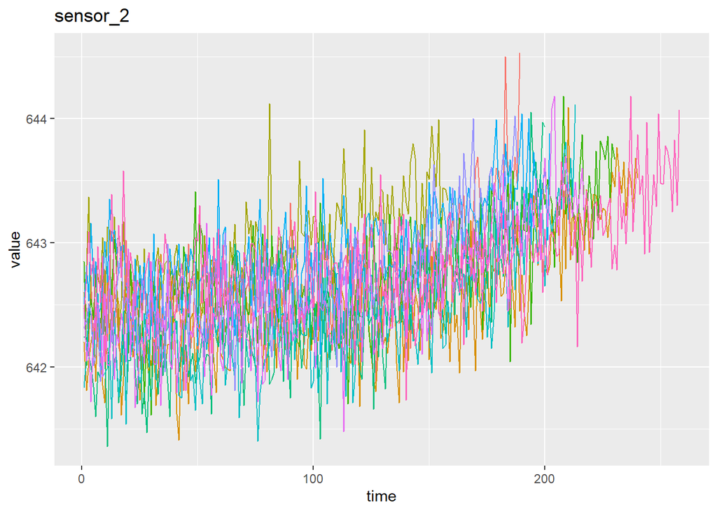

#### 3.1.1.2 sensor_3

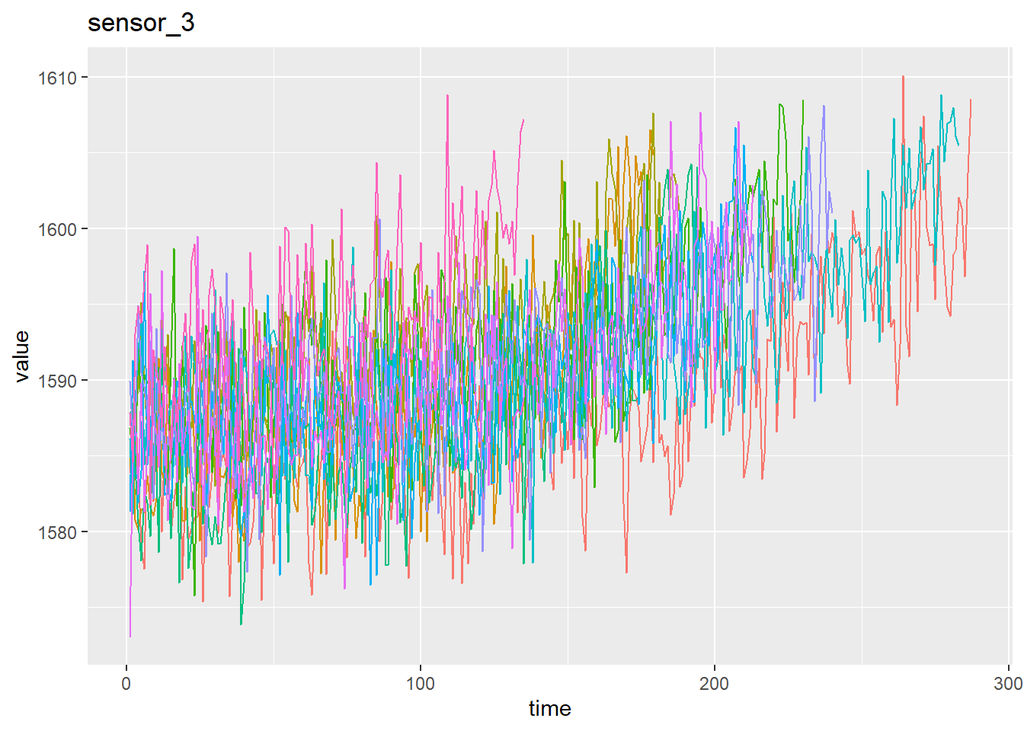

#### 3.1.1.3 sensor_4

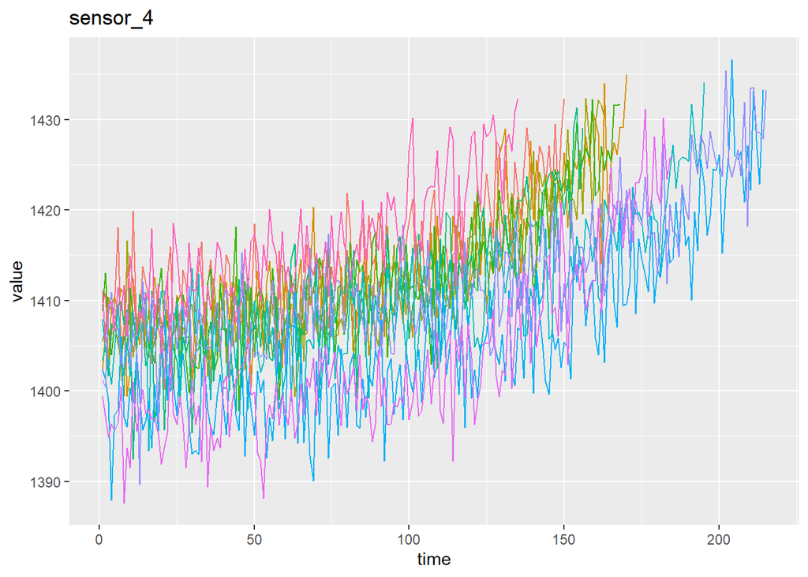

#### 3.1.1.4 sensor_6

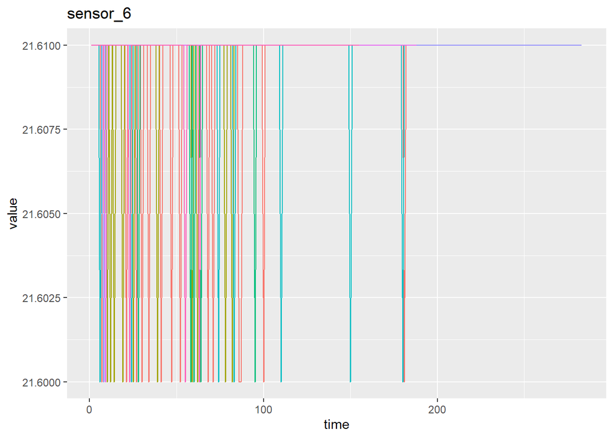

#### 3.1.1.5 sensor_7

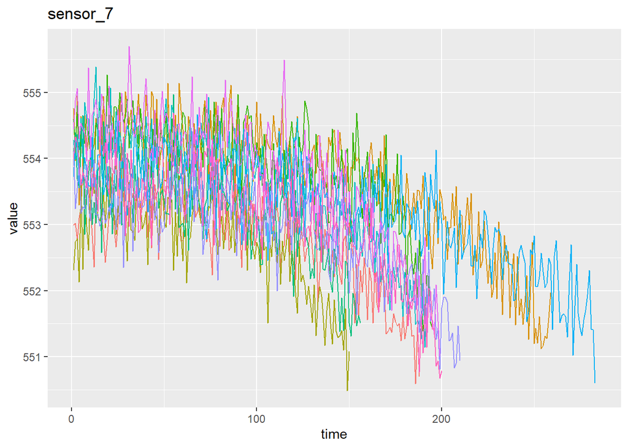

#### 3.1.1.6 sensor_8

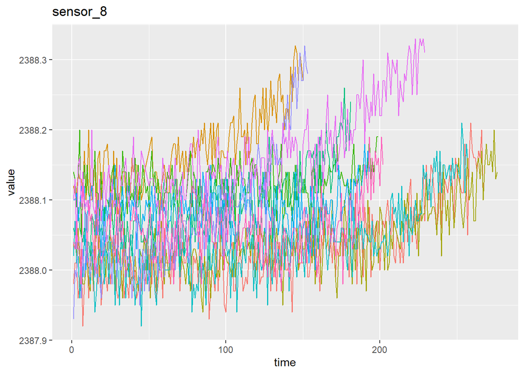

#### 3.1.1.7 sensor_9

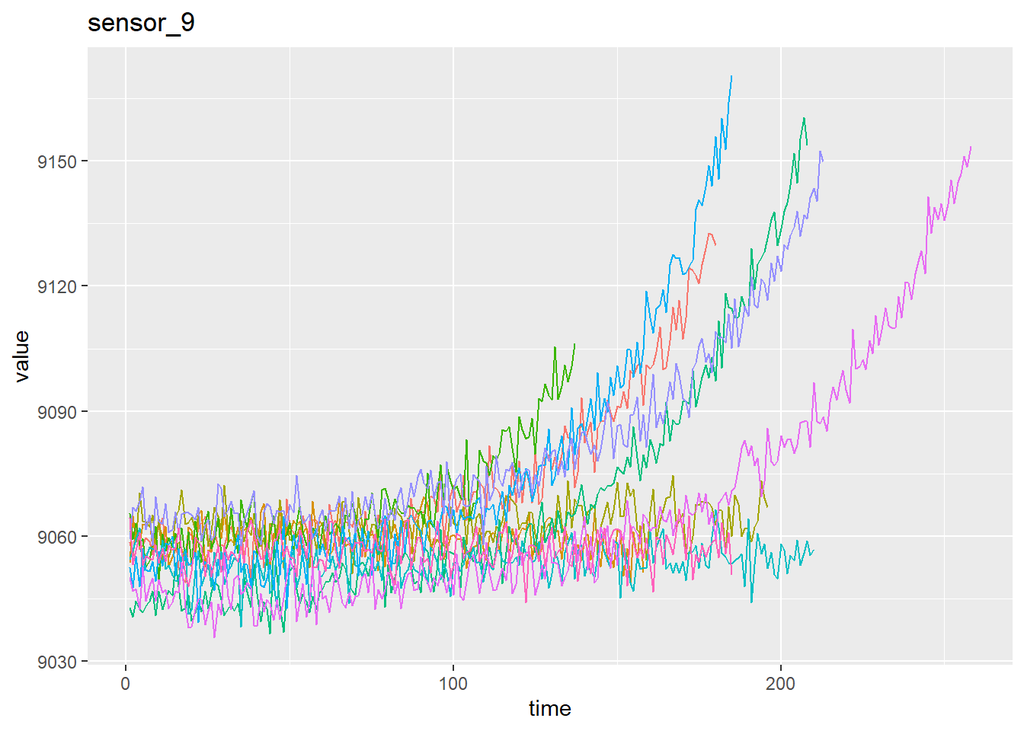

#### 3.1.1.8 sensor_11

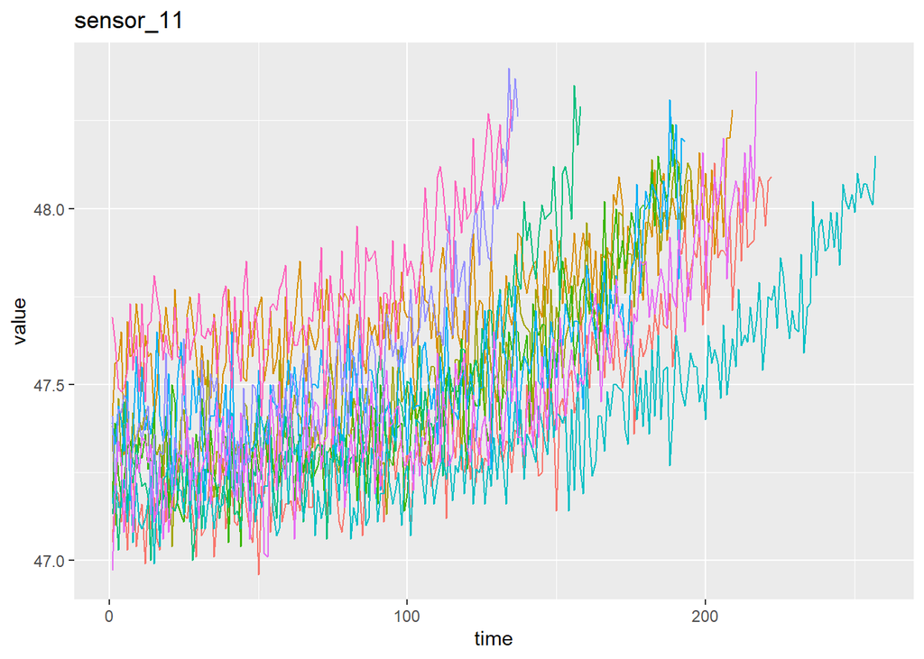

#### 3.1.1.9 sensor_12

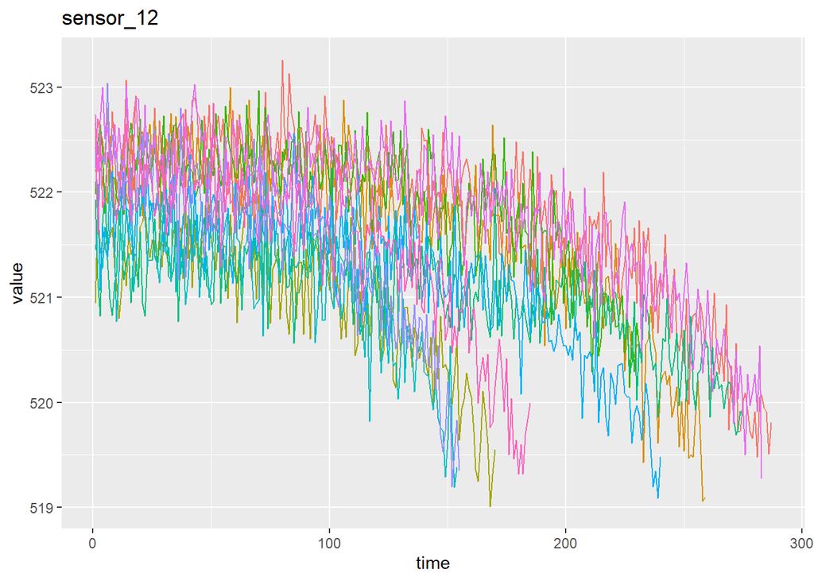

#### 3.1.1.10 sensor_13

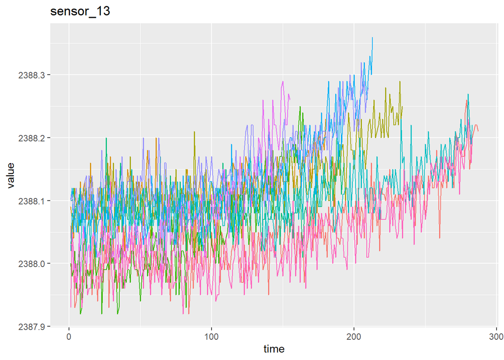

#### 3.1.1.11 sensor_14

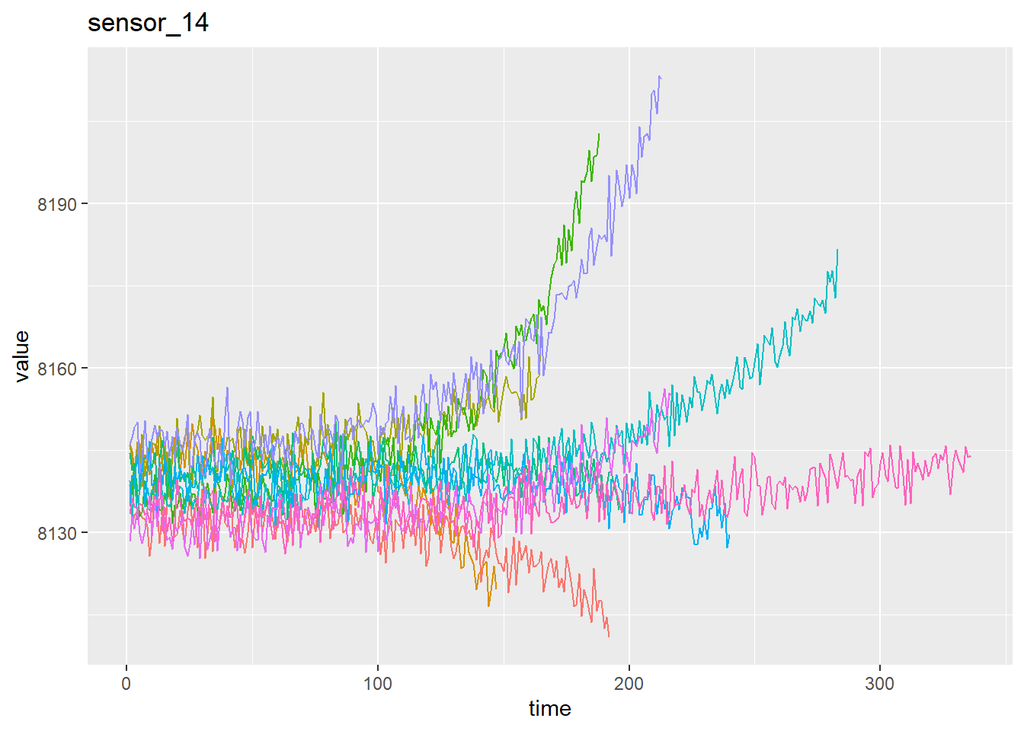

#### 3.1.1.12 sensor_15

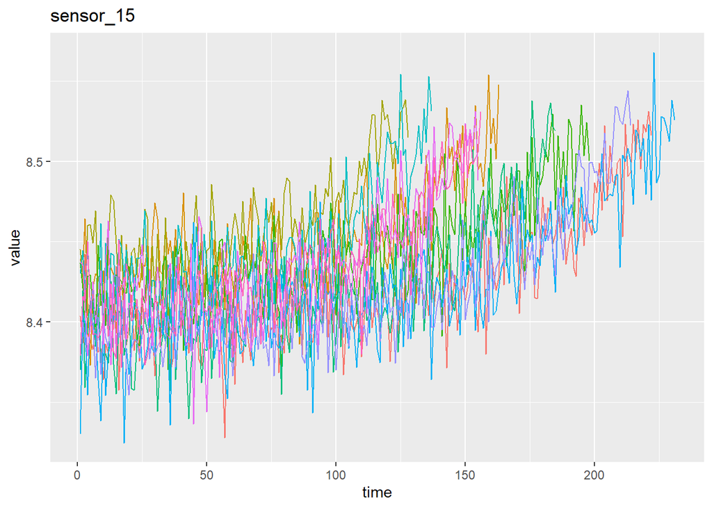

#### 3.1.1.13 sensor_17

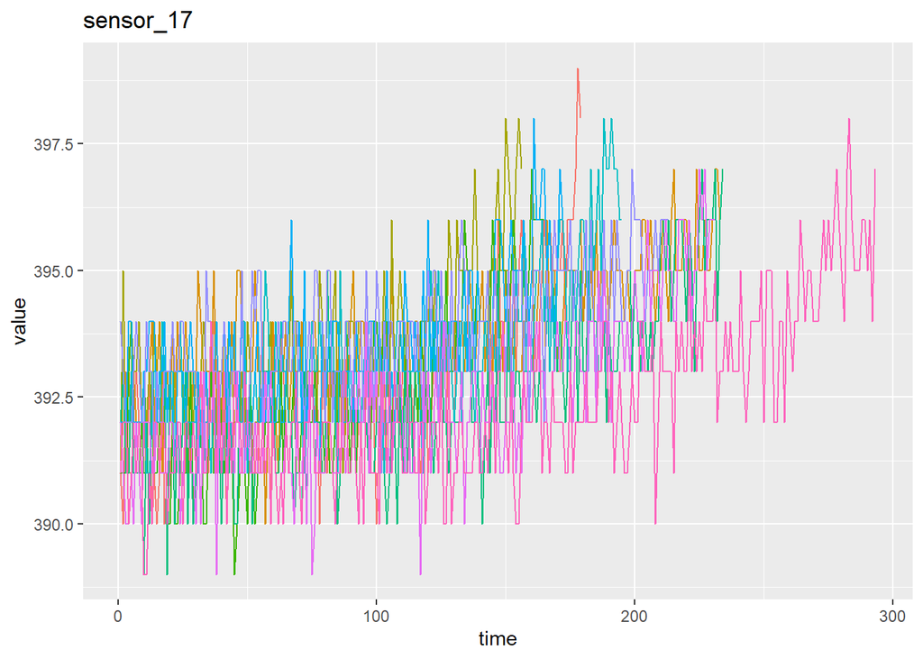

#### 3.1.1.14 sensor_20

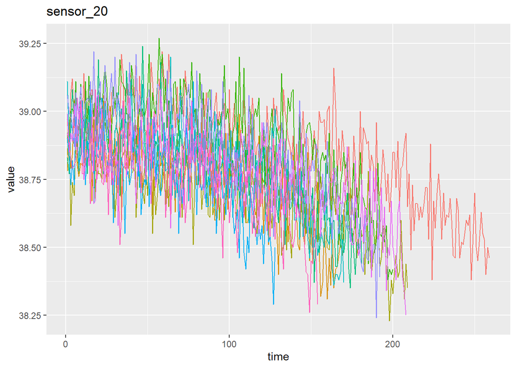

#### 3.1.1.15 sensor_21

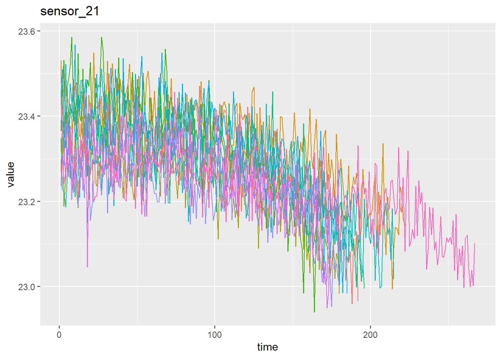

## 3.2 Complicated dataset

```r
  data4 %>% group_by(setting) %>%
  summarise( across(-(1:5), list(mean = mean), .names = "{.col}") ) %>%
  rbind(.,
        data4 %>% group_by(setting) %>%
          summarise( across(-(1:5), list(mean = sd), .names = "{.col}") )
        ) %>%
  # cbind(
  #   list(stat = c("mean","standard_dev")) %>% as.data.frame(.),
  #   .) %>%
  `rownames<-`(c(paste("mean for setting",1:6),paste("sd",1:6))) %>%
  #print()
  #knitr::kable() -> a
  #scroll_box(width = "100%")

  rmarkdown::paged_table(options = list(rows.print = 12))
```

|  | setting | sensor_1 | sensor_2 | sensor_3 | sensor_4 | sensor_5 | sensor_6 | sensor_7 | sensor_8 | sensor_9 | sensor_10 | sensor_11 | sensor_12 | sensor_13 | sensor_14 | sensor_15 | sensor_16 | sensor_17 | sensor_18 | sensor_19 | sensor_20 | sensor_21 | RUL |
| --- | --- | --- | --- | --- | --- | --- | --- | --- | --- | --- | --- | --- | --- | --- | --- | --- | --- | --- | --- | --- | --- | --- | --- |
| mean for setting 1 | 86 | 462.54 | 536.7385896 | 1260.672766 | 1046.772438 | 7.05 | 9.01824488 | 175.764793 | 1915.4118317 | 8014.08920 | 0.939715505 | 36.6877339 | 164.8774581 | 2028.3103775 | 7877.95826 | 10.86451581 | 0.0200000000 | 306.824926 | 1915 | 84.93 | 14.3101083 | 8.58719558 | 132.81759 |
| mean for setting 2 | 100 | 518.67 | 642.4967385 | 1588.519059 | 1405.249438 | 14.62 | 21.59928231 | 555.114113 | 2388.0842444 | 9063.49229 | 1.301241611 | 47.4400963 | 523.0318857 | 2388.0840301 | 8143.46468 | 8.40041147 | 0.0300000000 | 392.673306 | 2388 | 100.00 | 38.9766605 | 23.38888031 | 132.82875 |
| mean for setting 3 | 110 | 489.05 | 604.7005746 | 1500.003491 | 1307.423831 | 10.52 | 15.48232979 | 395.403328 | 2318.9404965 | 8785.88814 | 1.260671075 | 45.3751518 | 372.4466479 | 2388.1432643 | 8136.94614 | 8.62148688 | 0.0299956635 | 369.188855 | 2319 | 100.00 | 28.6366446 | 17.18113389 | 134.85668 |
| mean for setting 4 | 121 | 491.19 | 607.3267242 | 1483.501860 | 1249.568890 | 9.35 | 13.63941261 | 335.213732 | 2324.0008426 | 8729.25549 | 1.078039820 | 44.3409416 | 315.5326015 | 2388.1323232 | 8066.97306 | 9.19051614 | 0.0216092839 | 364.825872 | 2324 | 100.00 | 24.5338049 | 14.72113987 | 133.49423 |
| mean for setting 5 | 136 | 449.44 | 555.5645416 | 1364.709756 | 1128.238337 | 5.48 | 7.99069199 | 194.903643 | 2223.0409703 | 8355.91217 | 1.023427199 | 41.8765204 | 183.4438332 | 2388.1383464 | 8073.66592 | 9.28839676 | 0.0200000000 | 333.727680 | 2223 | 100.00 | 14.8824623 | 8.92979229 | 132.76304 |
| mean for setting 6 | 143 | 445.00 | 549.4779123 | 1352.562715 | 1124.490963 | 3.91 | 5.70802988 | 138.928309 | 2212.0051790 | 8327.56420 | 1.022520299 | 42.0373271 | 130.8244196 | 2388.0895538 | 8090.70789 | 9.33187756 | 0.0200000000 | 330.543813 | 2212 | 100.00 | 10.6228477 | 6.37269761 | 133.18675 |
| sd 1 | 86 | 0.00 | 0.3859149 | 5.818127 | 7.476698 | 0.00 | 0.01216113 | 1.040066 | 0.2106214 | 13.29292 | 0.001813724 | 0.2411951 | 0.9584518 | 0.2233178 | 11.74704 | 0.07285661 | 0.0000000000 | 1.434721 | 0 | 0.00 | 0.1281494 | 0.07644723 | 88.82467 |
| sd 2 | 100 | 0.00 | 0.5144157 | 6.707031 | 9.731900 | 0.00 | 0.01489940 | 3.468158 | 0.1485085 | 19.27106 | 0.003504721 | 0.2956727 | 3.2797159 | 0.1486784 | 16.08195 | 0.06104204 | 0.0000000000 | 1.725006 | 0 | 0.00 | 0.2538452 | 0.15225850 | 90.29535 |
| sd 3 | 110 | 0.00 | 0.5171578 | 6.537669 | 9.392014 | 0.00 | 0.01474579 | 2.380231 | 0.1811438 | 18.89391 | 0.003136734 | 0.2923286 | 2.2399145 | 0.1858479 | 15.98410 | 0.06194252 | 0.0002082091 | 1.649454 | 0 | 0.00 | 0.1921737 | 0.11542468 | 90.82645 |
| sd 4 | 121 | 0.00 | 0.5083340 | 6.635482 | 8.893205 | 0.00 | 0.02312558 | 2.121665 | 0.2052683 | 17.82136 | 0.005716723 | 0.2831737 | 1.9940436 | 0.2109515 | 15.17650 | 0.06494879 | 0.0036748510 | 1.679991 | 0 | 0.00 | 0.1740929 | 0.10393227 | 89.82861 |

[output cut: 2 more lines]

```r
zero_sd_selector <- data4 %>% group_by(setting) %>%
  summarise( across(-(1:5), sd, .names = "{.col}")) %>%
  abs() %>%
  colSums() %>%
  as.numeric() == 0
zero_sd_selector <- zero_sd_selector[-1]
# sensors which have 0 sd
constant_sensors <- data4 %>%
  select(-c(1:5) & ! matches("setting")) %>%
  .[zero_sd_selector] %>%
  names()
saveRDS(constant_sensors,file = here("objects/constant_sensors_data4.rds"))
sensors_all <- colnames(data4) %>% str_subset("sensor.*")
# set difference
sensors <- setdiff(sensors_all,constant_sensors)
```

As we can see sensors with the following numbers: 1, 5, 18, 19 have zero standard deviation which means that they are constant. We will disregard them in further analysis as they carry no information.

```r
l_plt_c <- list()
for (i in seq_along(sensors)) {

sensor_to_plot <- sensors[i]
no_of_units_to_draw <- 10
units_to_plot <- sample(data4$unit_no %>% unique(),no_of_units_to_draw)
setting_to_plot <- data4$setting %>% unique() %>%  sample(1)

l_plt_c[[i]] <- data4 %>%
  select(-constant_sensors) %>%
  pivot_longer(cols = sensors, names_to = "sensor", values_to = "value") %>%
  filter(unit_no %in% units_to_plot & sensor == sensor_to_plot & setting == setting_to_plot ) %>%
  ggplot(aes(x=time, y=value, color = factor(unit_no)))+
  geom_line(show.legend = F)+
  ggtitle(paste(sensor_to_plot,"setting:",setting_to_plot))


}
```

```r
for (i in seq_along(sensors)) {
  tmp <- l_plt_c[[i]]
  cat("####",sensors[i],"\n")
  print(tmp)
  cat("\n\n")
}
```

#### 3.2.1.1 sensor_2

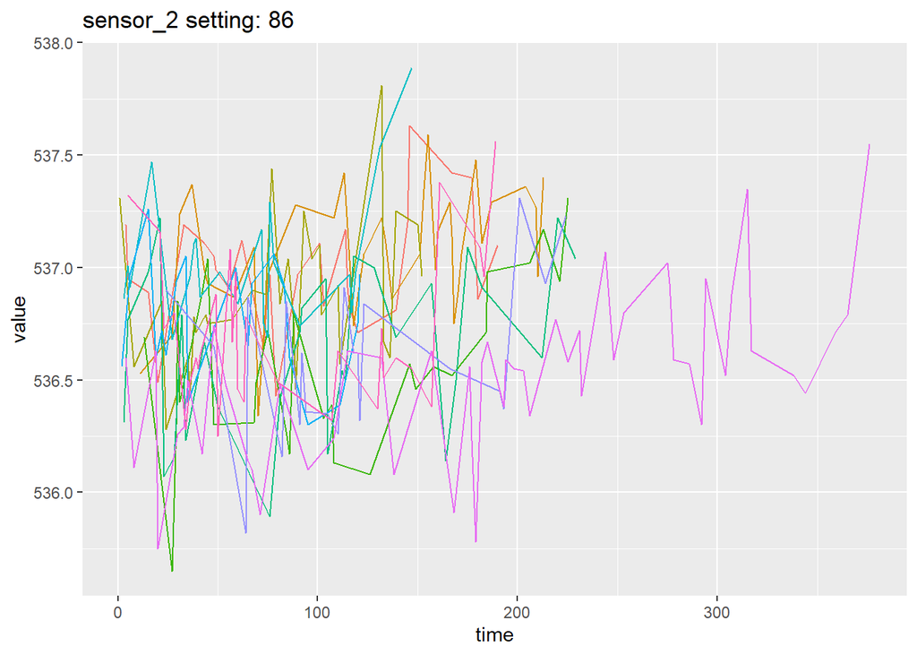

#### 3.2.1.2 sensor_3

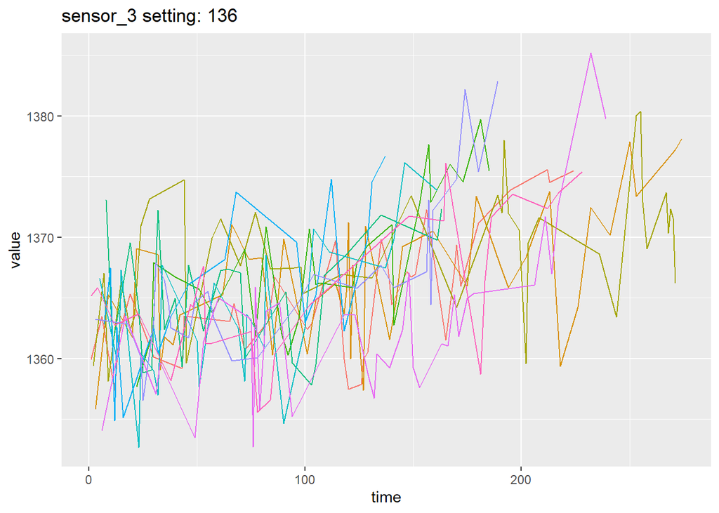

#### 3.2.1.3 sensor_4

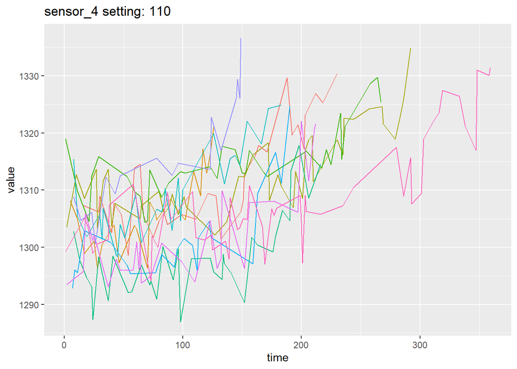

#### 3.2.1.4 sensor_6

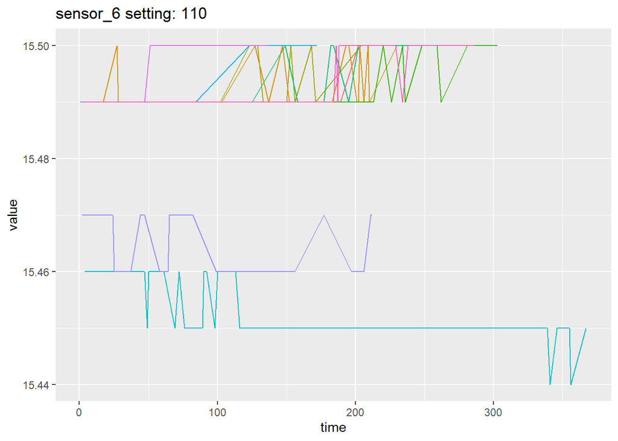

#### 3.2.1.5 sensor_7

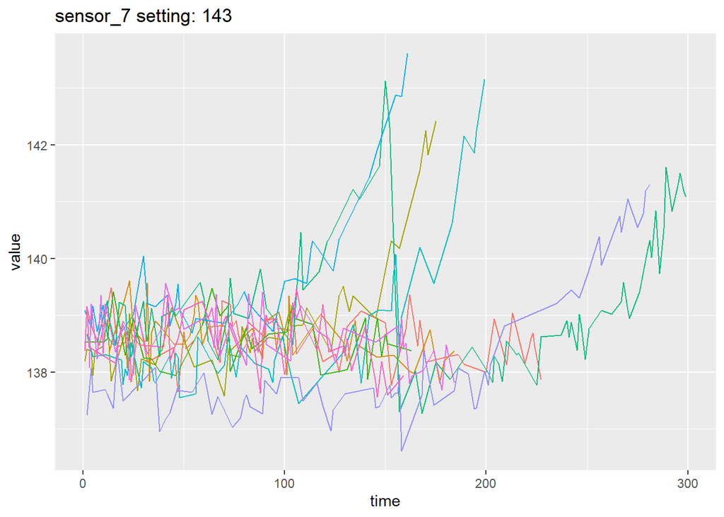

#### 3.2.1.6 sensor_8

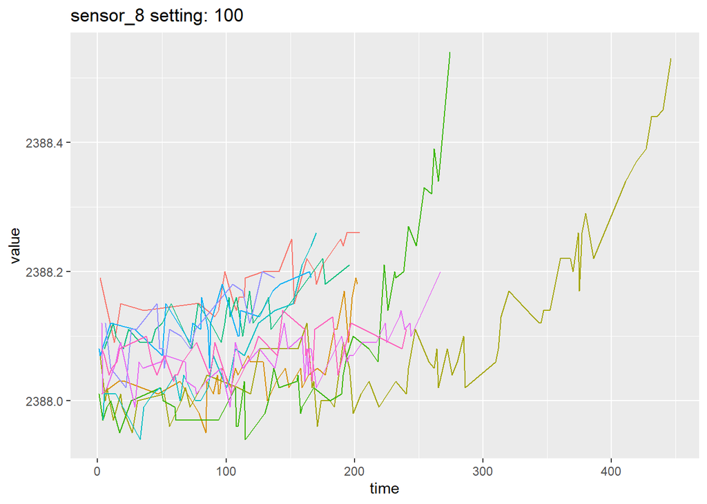

#### 3.2.1.7 sensor_9

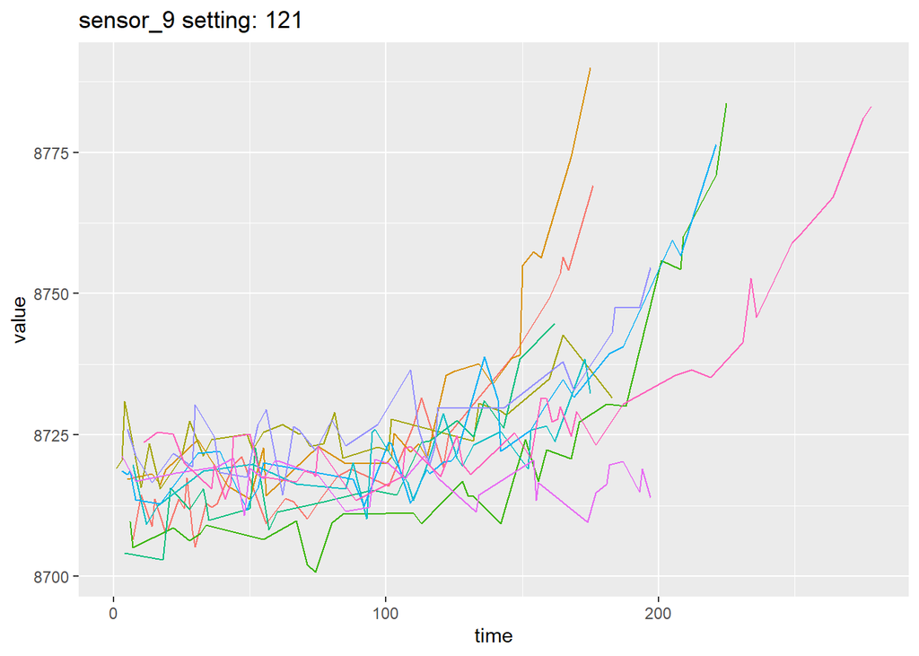

#### 3.2.1.8 sensor_10

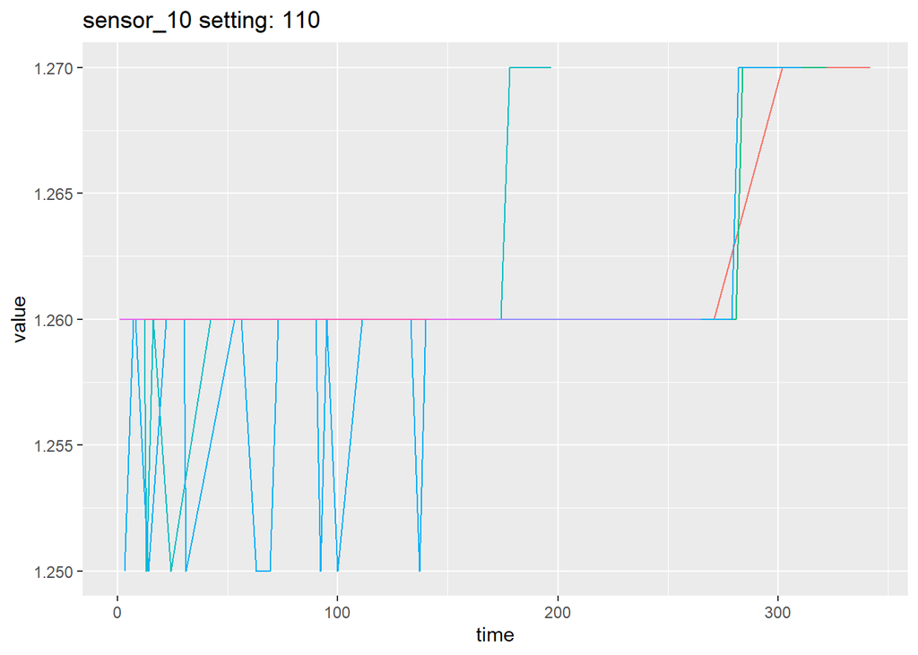

#### 3.2.1.9 sensor_11

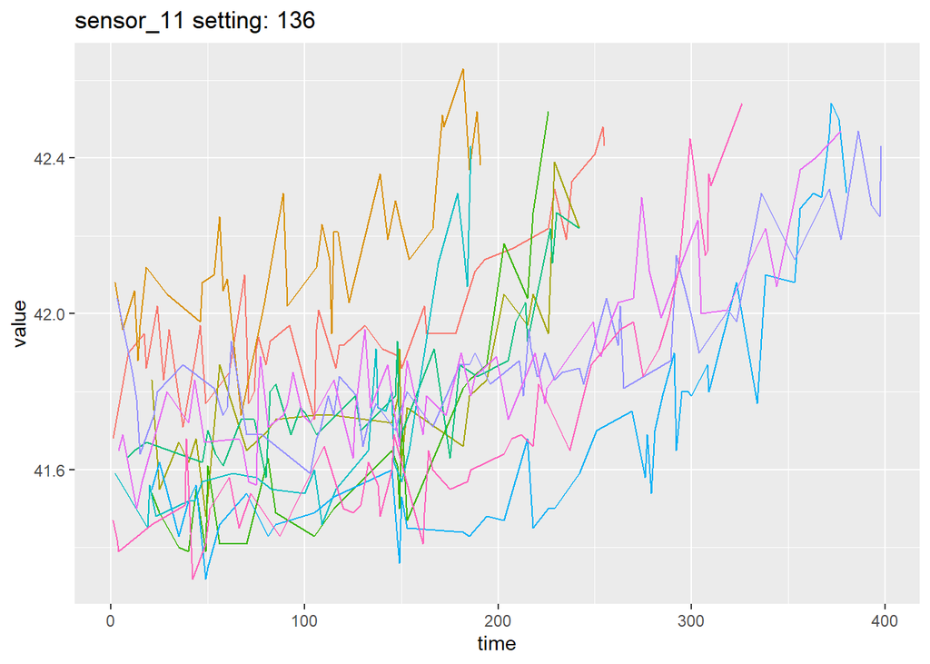

#### 3.2.1.10 sensor_12

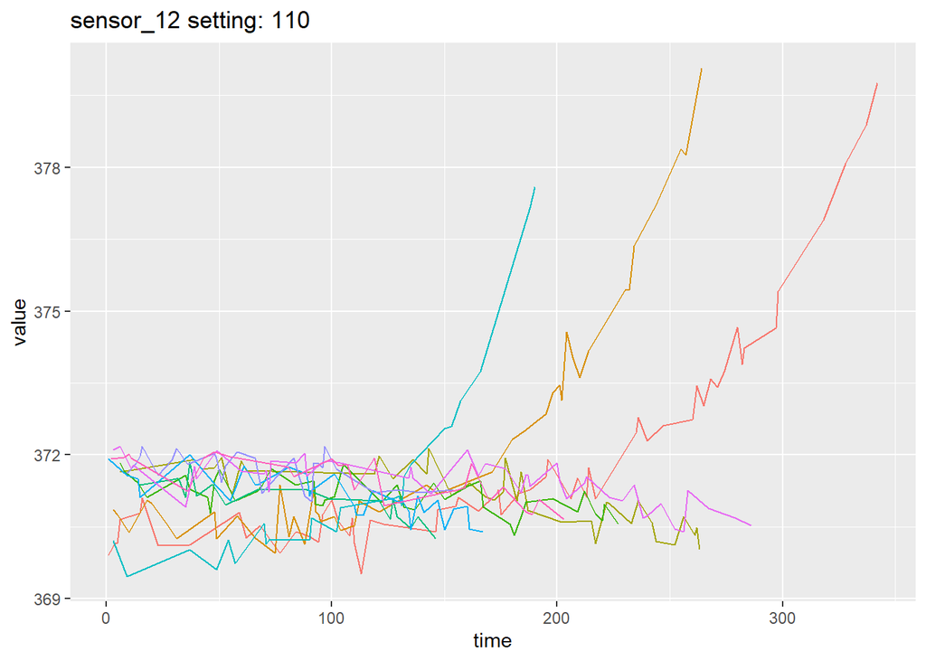

#### 3.2.1.11 sensor_13

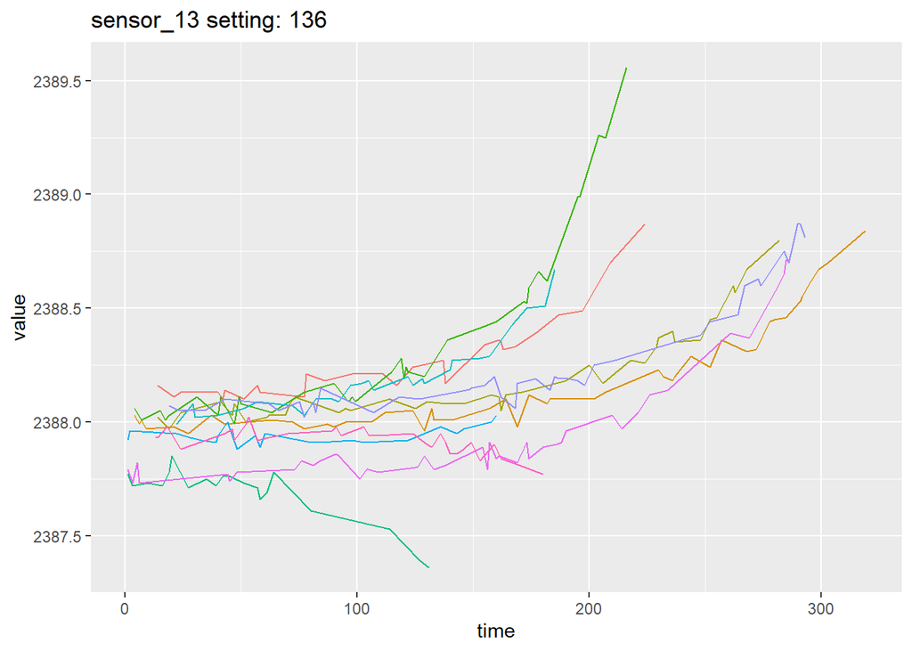

#### 3.2.1.12 sensor_14

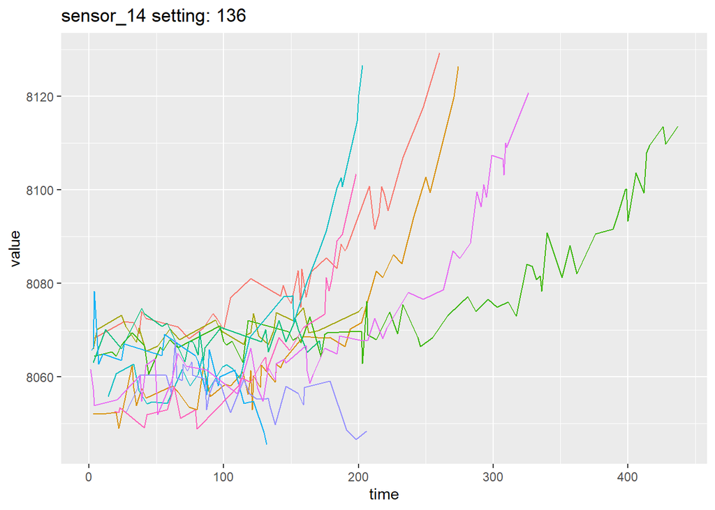

#### 3.2.1.13 sensor_15

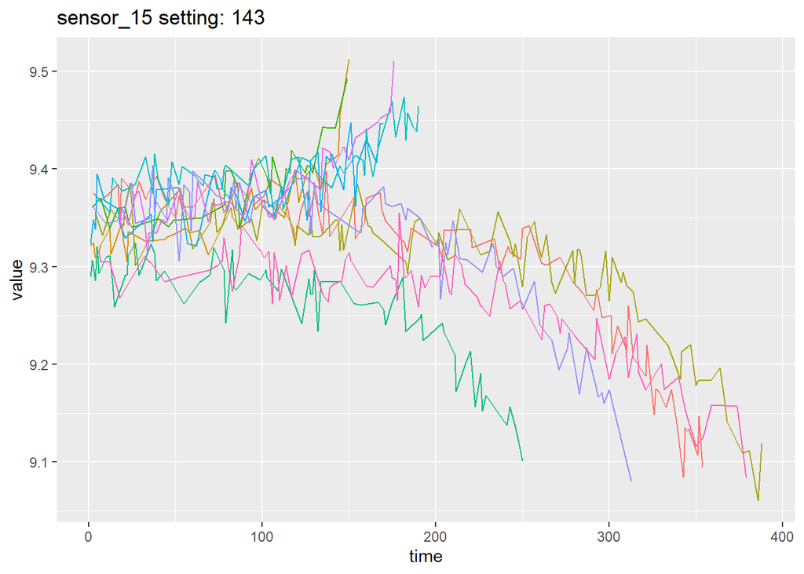

#### 3.2.1.14 sensor_16

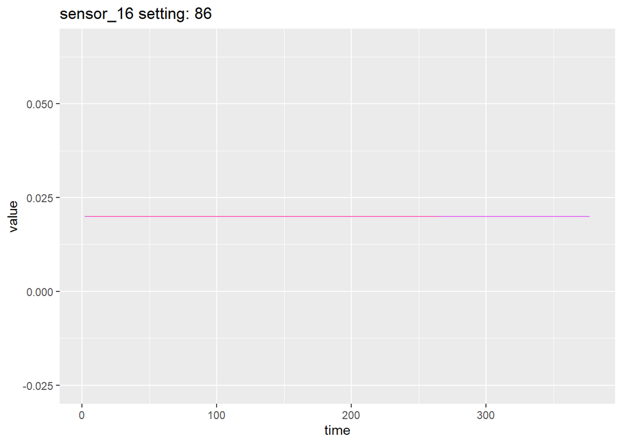

#### 3.2.1.15 sensor_17

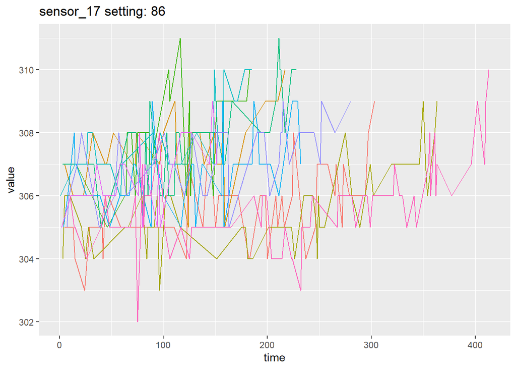

#### 3.2.1.16 sensor_20

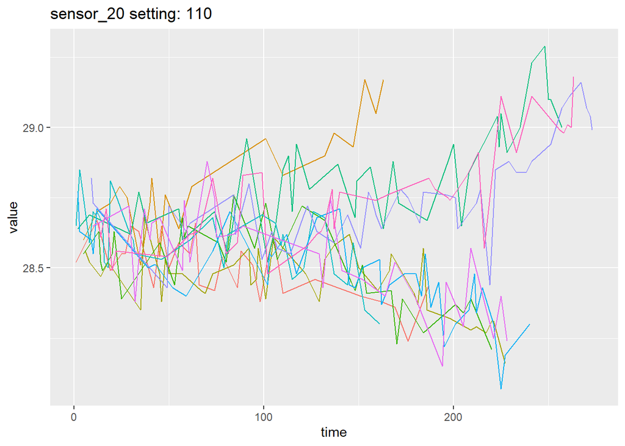

#### 3.2.1.17 sensor_21

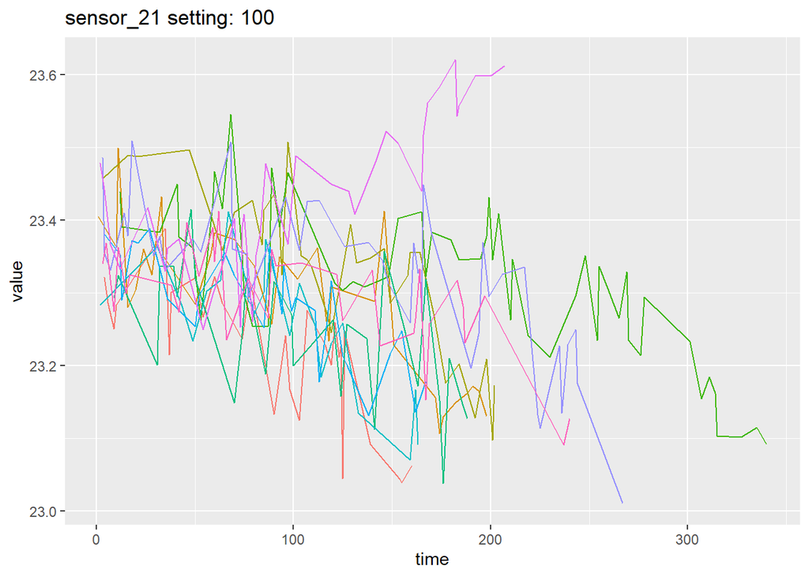